# Abstract

When people are buying or selling a house, the biggest thing they care about is the sales price. Buyers usually have their dream house checklist including: number of bedrooms/bathrooms, house age, kitchen finishes, and the quality of the schools and surronding neighborhood. Sellers want to know what factors impact the sales price the most. An example of this is whether doing a last minute remodel or staging the house correctly can increase the value of their housel

I got my dataset from Kaggle, it has 79 explanatory variables describing (almost) every aspect of residential homes in Ames, Iowa. The goal of this project is to build a model to predict the final house sale price of each home using Python. Additionally I wanted try to find out the features that have the biggest influcene on the final price.

# Overview

This project is using Python langugage. The package I'm using are pandas, numpy,matplotlib, seaborn, sklearn scipy.stats etc. These package are very powerful when doing anaysis and building models.

Quantitative: 1stFlrSF, 2ndFlrSF, 3SsnPorch, BedroomAbvGr, BsmtFinSF1, BsmtFinSF2, BsmtFullBath, BsmtHalfBath, BsmtUnfSF, EnclosedPorch, Fireplaces, FullBath, GarageArea, GarageCars, GarageYrBlt, GrLivArea, HalfBath, KitchenAbvGr, LotArea, LotFrontage, LowQualFinSF, MSSubClass, MasVnrArea, MiscVal, MoSold, OpenPorchSF, OverallCond, OverallQual, PoolArea, ScreenPorch, TotRmsAbvGrd, TotalBsmtSF, WoodDeckSF, YearBuilt, YearRemodAdd, YrSold

Qualitative: Alley, BldgType, BsmtCond, BsmtExposure, BsmtFinType1, BsmtFinType2, BsmtQual, CentralAir, Condition1, Condition2, Electrical, ExterCond, ExterQual, Exterior1st, Exterior2nd, Fence, FireplaceQu, Foundation, Functional, GarageCond, GarageFinish, GarageQual, GarageType, Heating, HeatingQC, HouseStyle, KitchenQual, LandContour, LandSlope, LotConfig, LotShape, MSZoning, MasVnrType, MiscFeature, Neighborhood, PavedDrive, PoolQC, RoofMatl, RoofStyle, SaleCondition, SaleType, Street, Utilities.

Our target variable is SalePrice. It is numerical, so regression algorithms are proper candidates.

The Overall project will including data cleaning, data preprocessing, building and validating models.

```python
import nbconvert
import pandas as pd
import numpy as np
import matplotlib.pyplot as plt
import seaborn as sns
import sklearn
from sklearn.linear_model import LinearRegression, Ridge, ElasticNet, Lasso
from sklearn.tree import DecisionTreeRegressor
from sklearn.ensemble import RandomForestRegressor
from sklearn.ensemble import GradientBoostingRegressor
from sklearn.model_selection import KFold, cross_val_score, train_test_split
from sklearn.svm import SVR, LinearSVR
from sklearn.neighbors import KNeighborsRegressor
import xgboost as xgb
from sklearn.model_selection import GridSearchCV
import missingno as msno
import scipy.stats as st
from collections import Counter
from sklearn.preprocessing import PowerTransformer
from scipy.stats import norm,probplot
%matplotlib inline
sns.set
pd.options.display.max_columns = 90
```

```python
train=pd.read_csv('/Users/huitingsheng/Downloads/Github/Predict-House-Sale-Price/train.csv')
test=pd.read_csv('/Users/huitingsheng/Downloads/Github/Predict-House-Sale-Price/test.csv')
test_saleprice=pd.read_csv('/Users/huitingsheng/Downloads/Github/Predict-House-Sale-Price/sample_submission.csv')
train_data = train.copy()
test_data = test.copy()
Y_test = test_saleprice.copy()

print("train data shape is: ",train_data.shape)
print("test data shape is : ",test_data.shape)
print("test sale price data is: ",Y_test.shape)
```

```
train data shape is:  (1460, 81)
test data shape is :  (1459, 80)
test sale price data is:  (1459, 2)
```

Test dataset has 1 feature less than train dataset. The missing feature is SalePrice which is what I am trying to predict. test sale price data have two columns: Id and SalePrice. I will drop Id later.

Let's take a look of what features do we have.

# Exploratory Data Analytics (EDA)

## Target variable: Sales Price Analysis

First thing first, let take a look of the target variable, SalePrice. The SalePrice is skewed, the skewness is 1.88, and kurtosis is 6.5. it is not normalized. Log transformation is a proper one. after log transformed, it is much mormalized, the skewness is 0.12 and kurtosis is 0.81.

```
The SalePrice skewness is: 1.882876
The SalePrice kurtosis is: 6.536282
```

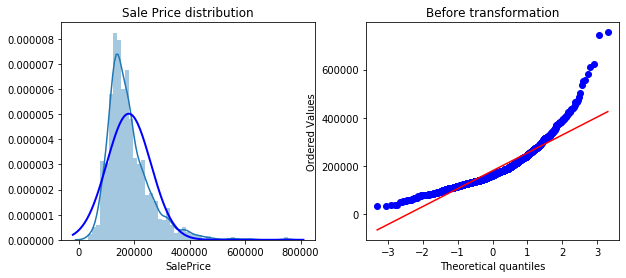

```python
fig, axes = plt.subplots(1, 2, figsize = (10,4))
plt.figure(1); plt.title('Sale Price distribution')
sns.distplot(train_data["SalePrice"], kde=True, fit=st.norm,
             fit_kws={"color":"blue","lw": 2, "label": "norm"},
             ax=axes[0]).set_title("Sale Price distribution")
probplot(train_data['SalePrice'], plot=plt)
plt.title("Before transformation")
print("The SalePrice skewness is: %f" % train_data["SalePrice"].skew())
print("The SalePrice kurtosis is: %f" % train_data["SalePrice"].kurtosis())
```

```
The skewness is: 0.121335
The kurtosis is: 0.809532
```

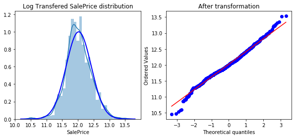

```python
# SalePrice log transformation
fig, axes = plt.subplots(1, 2, figsize = (10,4))
plt.figure(1); plt.title('log transformed Sale Price distribution')
sns.distplot(np.log(train_data["SalePrice"]), kde=True, fit=st.norm,
             fit_kws={"color":"blue","lw": 2, "label": "norm"},
             ax=axes[0]).set_title("Log Transfered SalePrice distribution")
probplot(np.log(train_data["SalePrice"]), plot=plt)
plt.title("After transformation")
print("The skewness is: %f" % np.log(train_data["SalePrice"]).skew())
print("The kurtosis is: %f" % np.log(train_data["SalePrice"]).kurtosis())
```

Based on the distribution plot and Q~Q plot, SalePrice is right skewed that doesn't follow normal distribution. After log transfomation, the log(SalePrice) becomes normal distributed.

## Numerical features vs Sale Price

Next let's take a look all numerical features, and see what are the most related features to Sale Price. The below plot shows the absolute correlation between numerical features and Sale price. We can see not all variables have strong relationship with sale price. The top 5 variables are OverallQual,GrLivArea, GarageCars, GarageArea, TotalBsmtSF. The bottom 5 variables are LowQualFinSF, Id, MiscVal, BsmtHalfBath, BsmtFinSF2.

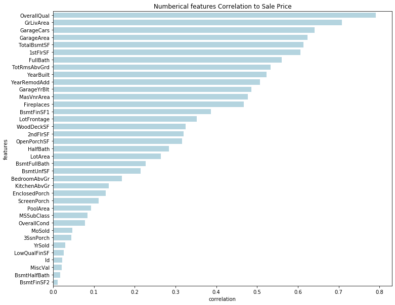

```python
# lets see the correlation between columns and target column
corrmat = train_data.corr()
price_corr = abs(corrmat["SalePrice"]).sort_values(ascending= False)[1:]

num_price_corr = pd.DataFrame({'features':price_corr.index, 'correlation':price_corr.values})

plt.subplots(figsize=(12, 10))
sns.barplot(x = 'correlation', y = 'features', data = num_price_corr, color="lightblue",
            edgecolor = 'w').set_title('Numberical features Correlation to Sale Price')
```

## Ordinal Features vs Sale Price

There are also a lot of features that are ordinal features, for example, Kitchen quality, External quality, External Condition, Garage quality etc. Below are some example. We can tell the better quality, the higher sale price. some impact the sale price more, some less.

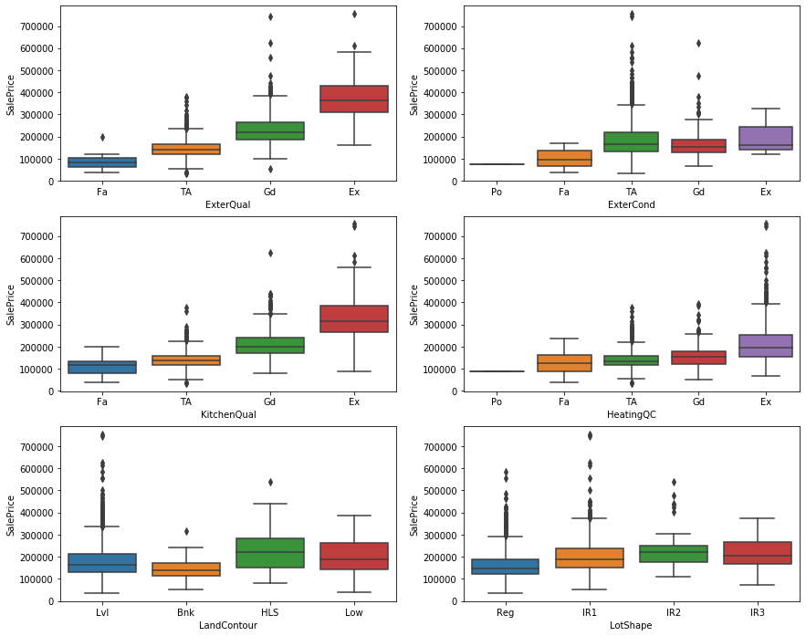

```python
fig, axes = plt.subplots(3, 2, figsize = (6,12))
plt.subplots_adjust(right=2)

sns.boxplot(data= train_data, x='ExterQual', y = "SalePrice",
            order= ["Fa","TA","Gd", "Ex"], ax=axes[0,0])
sns.boxplot(data= train_data, x='ExterCond', y = "SalePrice",
            order= ["Po","Fa","TA","Gd", "Ex"], ax=axes[0,1])

sns.boxplot(data= train_data, x='KitchenQual', y = "SalePrice",
            order= ["Fa","TA","Gd", "Ex"], ax=axes[1,0])
sns.boxplot(data= train_data, x='HeatingQC', y = "SalePrice",
            order= ["Po","Fa","TA","Gd", "Ex"], ax=axes[1,1])

sns.boxplot(data= train_data, x='LandContour', y = "SalePrice",
            order= ["Lvl","Bnk","HLS","Low"], ax=axes[2,0])

sns.boxplot(data= train_data, x='LotShape', y = "SalePrice",
            order= ["Reg","IR1","IR2","IR3"], ax=axes[2,1])
```

## Categorical features vs Sale Price

There are also many categorical features, such as MSSubClass, MSZoning, Utilities etc. Below are box plot for Neighborhood and HouseStyle. The house price are different in different Neighborhood

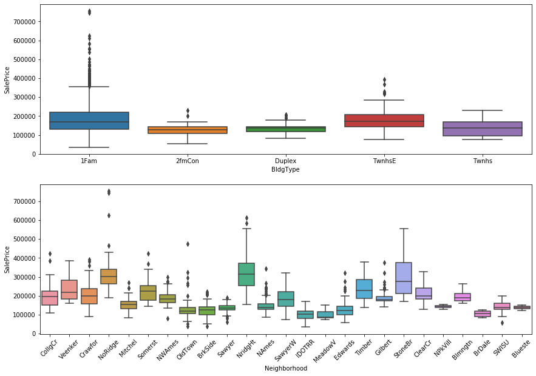

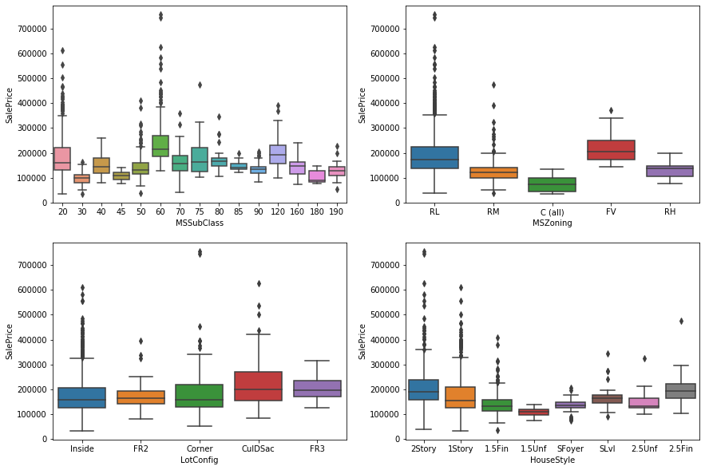

```python
#print(MSSubClass)
fig, axes = plt.subplots(2,1, figsize = (6,10))
plt.subplots_adjust(right=2)

#sns.boxplot(data= train_data, x='MSSubClass', y = "SalePrice", ax=axes[0,0])
sns.boxplot(data= train_data, x='BldgType', y = "SalePrice", ax=axes[0])
nb=sns.boxplot(data= train_data, x='Neighborhood', y = "SalePrice", ax=axes[1])
nb.set_xticklabels(nb.get_xticklabels(), rotation=45)
#sns.boxplot(data= train_data, x="HouseStyle", y="SalePrice", ax=axes[1,1])

#print(MSSubClass)
fig, axes = plt.subplots(2,2, figsize = (6,10))
plt.subplots_adjust(right=2)

sns.boxplot(data= train_data, x='MSSubClass', y = "SalePrice", ax=axes[0,0])
sns.boxplot(data= train_data, x='MSZoning', y = "SalePrice", ax=axes[0,1])
sns.boxplot(data= train_data, x='LotConfig', y = "SalePrice", ax=axes[1,0])
sns.boxplot(data= train_data, x="HouseStyle", y="SalePrice", ax=axes[1,1])
```

# Data Cleaning

Now that we have some insights about data, we need to preprocess them for the modeling part. The main steps are:

- Looking at potential NaN
- remove outlier
- remove unnecessary features
- data transformation
- Normalization
- Dealing with categorical features (e.g. Dummy coding)

Usually, in a real-world project, the test data are not available until the end. For this reason, test data should contain the same type of data of the training set to preprocess them in the same way. Here, the test set is available. It contains some observations not present in the training dataset and,the use of dummy coding could raise several issues (I spent a lot of time figuring out why I was not able to make predictions on the test set). The easiest way to solve this problem (that is not applicable if test data are not available) is to concatenate Train and Test sets, preprocess, and divide them again.

First Id need to be removed, it is unique value for each record, don't contribute any extra infomation for our model.

```python
Ytrain = np.log(train_data["SalePrice"])
train_id = train_data['Id']

train = train_data.drop(['SalePrice','Id'], axis = 1)
test = test_data.drop(['Id'],axis = 1)

# Concatenating train & test set
all_data = pd.concat([train,test], axis=0, sort=False)
#train_test = pd.concat([train_data,test_data], axis=0, sort=False).reset_index()
```

## Dealing with NA data

First check the missing data. And based on the data discription to fill in the missing records. There are few strategies I'm going to use:

- based on the defination, some features with no values means they don't have the feature, such as garage, fireplace etc, fill the missing value with None.
- fill the missing value with the appears most often value
- for numeric features, fill n/a with mean

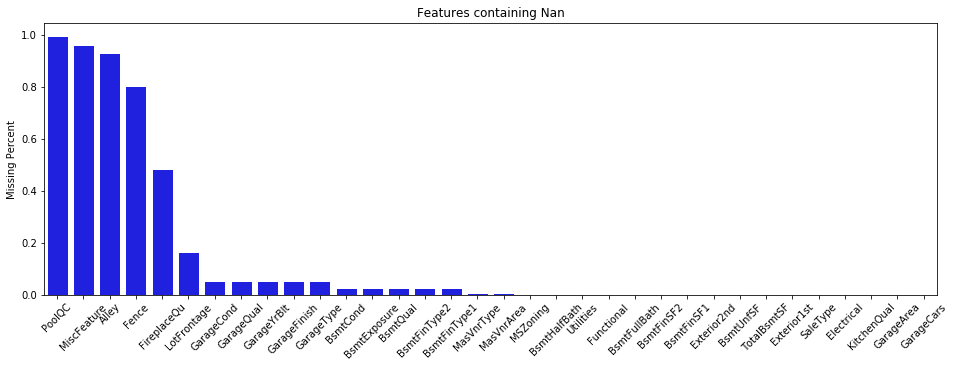

```python
# Null percentage for each column
missing_percent = (all_data.isnull().sum()/all_data.shape[0]).sort_values(ascending=False)
total_missing = all_data.isnull().sum().sort_values(ascending = False)

missing= pd.concat([total_missing, missing_percent], axis =1, keys =["Counts", "Missing Percent"])
missing[missing["Missing Percent"]>0]



plt.subplots(figsize=(16, 5))
missing_data = sns.barplot(x=missing[missing["Missing Percent"]>0].index, y = 'Missing Percent',
            data = missing[missing["Missing Percent"]>0],color="blue",
            edgecolor = 'w')#.set_title('Numberical features Correlation to Sale Price')
missing_data.set_xticklabels(missing_data.get_xticklabels(), rotation=45)
missing_data.set_title('Features containing Nan')
```

Features like PoolQC, MiscFeature, Alley, Fence, MasVnrType, FireplaceQu, GarageCond, GarageQual, GarageFinish, GarageType, BsmtCond, BsmtExposure, BsmtQual, BsmtFinType1, BsmtFinType2, the missing data are not really missing data, it means the house doesn't have the feature, So I fill the missing data with "None".

Feature related numerical features, like GarageYrBlt, GarageCars, GarageArea, MasVnrArea, BsmtFullBath, BsmtHalfBath, BsmtFinSF1, BsmtFinSF2, BsmtUnfSF, TotalBsmtSF,I fill the missing data with "0".

```python
# Filling Categorical NaN with None
NaN_Categorical_columns =["PoolQC","MiscFeature","Alley", "Fence", "MasVnrType","FireplaceQu", "GarageCond",
                          "GarageQual","GarageFinish","GarageType","BsmtCond","BsmtExposure",
                         "BsmtQual","BsmtFinType1","BsmtFinType2"]
#missing_features= train_missing[(train_missing["Counts"]>4) & (train_missing["Missing Percent"]<=0.3)].index
#print(missing_features)
for col in NaN_Categorical_columns:
    all_data[col].fillna('None',inplace=True)

Fill_0_Features = ["GarageYrBlt","GarageCars","GarageArea","MasVnrArea","BsmtFullBath","BsmtHalfBath","BsmtFinSF1",
                  "BsmtFinSF2","BsmtUnfSF","TotalBsmtSF"]
for col in Fill_0_Features:
    all_data[col].fillna(0,inplace=True)
```

```python
# fill with most common value or mean or other
all_data['MSZoning'].fillna(all_data['MSZoning'].mode()[0],inplace=True)
all_data['Functional'].fillna(all_data['Functional'].mode()[0],inplace=True)
all_data['Utilities'].fillna(all_data['Utilities'].mode()[0],inplace=True)
all_data['Electrical'].fillna(all_data['Electrical'].mode()[0],inplace=True)
all_data['KitchenQual'].fillna(all_data['KitchenQual'].mode()[0],inplace=True)
all_data['SaleType'].fillna("Oth",inplace=True)
all_data['Exterior2nd'].fillna("Other",inplace=True)
all_data['Exterior1st'].fillna("Other",inplace=True)

all_data = all_data.reset_index().drop('index',axis=1)
all_data['LotFrontage'] = all_data.groupby('Neighborhood')['LotFrontage'].apply(lambda x: x.fillna(x.median()))
```

```python
#visualising missing values
#msno.matrix(all_data, sort='descending')
all_data.isnull().sum().max()
```

```
0
```

## Outliers Detiction

After filling the Nan value, it turn to indentify outliers. I plot top 12 highest importance features against SalePrice. We can see there are some outliers that need to be removed. for example, There are two records that have very big great living area, but the sale price is low.

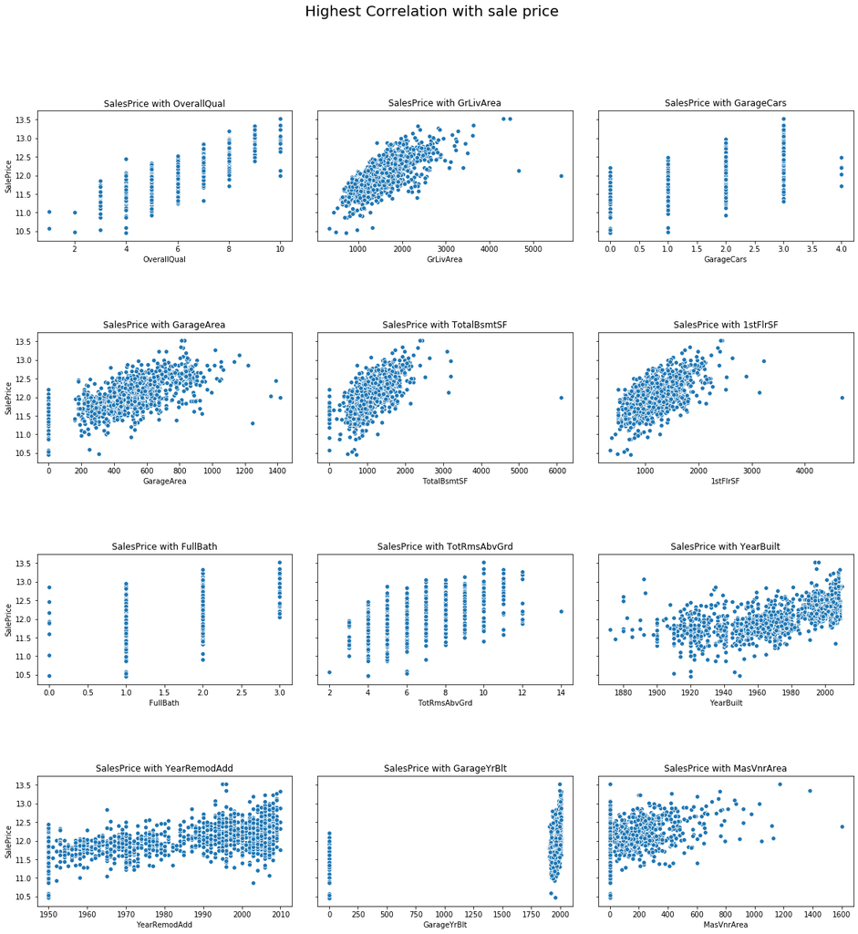

```python
# Outliers Detiction
#Visualize columns have corr with SalePrice
train_df = pd.concat([all_data.iloc[:1460,], Ytrain], axis=1, sort=False)
high_corr = corrmat['SalePrice'].sort_values(ascending=False)[1:][:13].index.tolist()

fig, axes = plt.subplots(4,3, figsize=(20, 20), sharey=True);
plt.subplots_adjust(hspace = 0.7, wspace=0.1)
fig.suptitle('Highest Correlation with sale price', fontsize=20);

for i,col in zip(range(12),high_corr):
    sns.scatterplot(y=train_df["SalePrice"], x=train_df[col], ax=axes[i//3][i%3])
    axes[i//3][i%3].set_title('SalesPrice with '+col)
```

```python
#outlier index
outlier_index = train_df[((train['GrLivArea']>4000) & (train_df['SalePrice']<12.5))|
                     ((train_df['GarageArea']>1200) & (train_df['SalePrice']<12.5))|
                    ((train_df['TotalBsmtSF']>5000) & (train_df['SalePrice']<12.5))|
                    ((train_df['TotalBsmtSF']>5000) & (train_df['SalePrice']<12.5))|
                     ((train_df['MasVnrArea']>1400) & (train_df['SalePrice']<12.5))|
                     ((train_df['SalePrice']>13.3))].index
```

## Remove Unuseful Features

When a feature that more than 90% data have same value, then the feature is useless. it does not bring too much information to the model. I will just remove them.

```python
del_var = []
var_perc = []
for var in all_data.columns:
    max_var_perc = all_data[var].value_counts().max()/all_data.shape[0]
    if max_var_perc > 0.9 :
        del_var.append(var)
        var_perc.append(max_var_perc)

var = pd.DataFrame({'features':del_var, 'most common value percentage':var_perc})

print(var)
```

```
        features  most common value percentage
0         Street                      0.995889
1          Alley                      0.932169
2      Utilities                      0.999657
3      LandSlope                      0.951696
4     Condition2                      0.989723
5       RoofMatl                      0.985269
6        Heating                      0.984584
7     CentralAir                      0.932854
8     Electrical                      0.915382
9   LowQualFinSF                      0.986297
10  BsmtHalfBath                      0.940048
11  KitchenAbvGr                      0.954094
12    Functional                      0.931483
13    GarageCond                      0.909215
14    PavedDrive                      0.904762
15     3SsnPorch                      0.987324
16   ScreenPorch                      0.912299
17      PoolArea                      0.995546
18        PoolQC                      0.996574
19   MiscFeature                      0.964029
20       MiscVal                      0.964714
```

## data transformation

Now it's time to do some data engeering. I will do following steps:

- generate a new feature Porch by adding all porch related data
- add new feature Remodel if the house has remodeled
- generate a new feature TotBathroom by add FullBath and halfBath togeter
- assign ordered number to all ordinal features, if the house doesn't have the featues, assign 0 to it.
- coverate data type
- remove all useless features

```python
def data_transformation(df):
    data = df.copy()
    data["Porch"] = data["OpenPorchSF"]+data["EnclosedPorch"] + data["3SsnPorch"] + data["ScreenPorch"]
    #data["CentralAir"]= data["CentralAir"].map({"Y":1, "N":0})
    #data["Electrical"] = data["Electrical"].apply(lambda x: 1 if x=="SBrkr" else 0)
    #data["Pool"] = data["PoolQC"].apply(lambda x: 0 if x=="None" else 1)
    data["TotBathroom"] = data["FullBath"] + 0.5* data["HalfBath"]
    data["Remodel"] = (data["YearRemodAdd"] - data["YearBuilt"]).apply(lambda x: 1 if x>1 else 0)

    colnames = ["BsmtFinSF1","BsmtFinSF2","BsmtUnfSF", #TotalBsmtSF = BsmtFinSF1+BsmtFinSF1 + BsmtUnfSF
                "OpenPorchSF","EnclosedPorch","3SsnPorch","ScreenPorch",
                "1stFlrSF","2ndFlrSF", #GrLivArea = 1stFlrSF + 2ndFlrSF
                "FullBath", "HalfBath", "YearRemodAdd",
                "GarageYrBlt", "BsmtFinType2"]
    delete_col= list(set(colnames) | set(del_var))

    data = data.drop(delete_col, axis=1, inplace=False)
    return data
```

### deal with ordinal features

There are lots of features are ordinal feature, we can label them as ordered numbers. for example, all Quality and Condition features, GarageFinish, BsmtFinType. etc. I'm going to label them as 0 if they don't have the feature, 1 if pool, 2 if Fair and so on.

```python
def ordinal_feature_transformation(df):
    data = df.copy()
    categorical_ordinal_feature = ["ExterQual","ExterCond","BsmtQual","BsmtCond","HeatingQC",
                                   "KitchenQual","FireplaceQu","GarageQual"]

    for i in categorical_ordinal_feature:
        data[i] = data[i].map({"None":0, "Po":1, "Fa":2, "TA":3, "Gd":4, "Ex":5})

    data['LotShape']= data["LotShape"].map({"Reg":4, "IR1":3, "IR2":2, "IR3":1})
    data['LandContour'] = data['LandContour'].map({"Lvl":4, "Bnk":3, "Low":2, "HLS":1})
    data["BsmtExposure"] = data["BsmtExposure"].map({"None":0, "No":1, "Mn":2, "Av":3, "Gd":4})
    data["BsmtFinType1"] = data["BsmtFinType1"].map({"None":0, "Unf":1, "LwQ":2, "Rec":3, "BLQ":4, "ALQ":5, "GLQ":6})
    #df["BsmtFinType2"] = df["BsmtFinType2"].map({"NA":0, "Unf":1, "LwQ":2, "Rec":3, "BLQ":4, "ALQ":5, "GLQ":6})
    data["GarageFinish"] = data["GarageFinish"].map({"None":0, "Unf":1, "RFn":2, "Fin":3})

    return data
```

### feature type converting

Based on the data defination, MSSubClass should be categorical data. We have two column YrSold and MoSold, I'm tying not to deal with time series, I will convert it to factor as well.

```python
# Converting non-numeric predictors stored as numbers into string

def type_convert(df):
    data = df.copy()
    data['MSSubClass'] = data['MSSubClass'].astype(object)
    data['YrSold'] = data['YrSold'].astype(object)
    data['MoSold'] = data['MoSold'].astype(object)
    data["LotArea"] = data["LotArea"].astype(float)
    data["BsmtFinType1"] = data["BsmtFinType1"].astype(int)
    data["GrLivArea"] = data["GrLivArea"].astype(float)
    data["WoodDeckSF"] = data["WoodDeckSF"].astype(float)
    data["BsmtFullBath"] = data["BsmtFullBath"].astype(int)
    data["GarageCars"] = data["GarageCars"]. astype(int)
    data["Porch"] = data["Porch"].astype(float)
    data["YearBuilt"] = data["YearBuilt"].astype(int)
    return data
```

## Normalization

As a general rule of thumb, a skewness with an absolute value > 0.5 is considered at least moderately skewed. There are 7 features that skewness greater than 0.5

```python
transfered_data = data_transformation(all_data)
transfered_data = ordinal_feature_transformation(transfered_data)
transfered_data = type_convert(transfered_data)
```

```python
# Differentiate numerical features (minus the target) and categorical features
categorical_features = transfered_data.select_dtypes(include = ["object"]).columns
numerical_features = transfered_data.select_dtypes(include = "float64").columns
ordinal_features = transfered_data.select_dtypes(include = "int64").columns
print("Numerical features : " + str(len(numerical_features)))

print("Ordinal features : " + str(len(ordinal_features)))

print("Categorical features : " + str(len(categorical_features)))

data_num = transfered_data[numerical_features]
data_cat = transfered_data[categorical_features]
data_od = transfered_data[ordinal_features]
```

```
Numerical features : 9
Ordinal features : 22
Categorical features : 18
```

```python
# As a general rule of thumb, a skewness with an absolute value > 0.5 is considered at least moderately skewed
skewness = data_num.apply(lambda x: x.skew())

skewness = skewness[abs(skewness) > 0.5]
print(skewness)
print(str(skewness.shape[0]) + " skewed numerical features to transform")
skewed_features = skewness.index
#train_num[skewed_features] = np.log1p(train_num[skewed_features])
```

```
LotFrontage     1.506478
LotArea        12.829025
MasVnrArea      2.614936
TotalBsmtSF     1.157489
GrLivArea       1.270010
WoodDeckSF      1.843380
Porch           2.238417
dtype: float64
7 skewed numerical features to transform
```

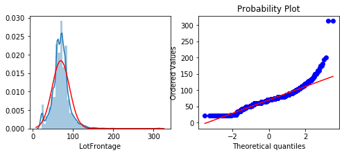

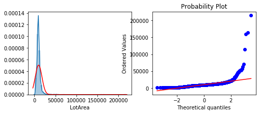

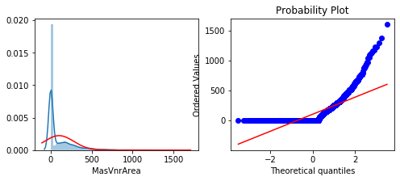

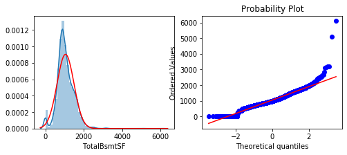

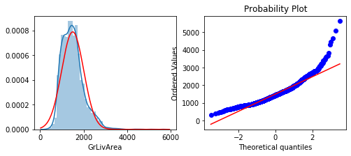

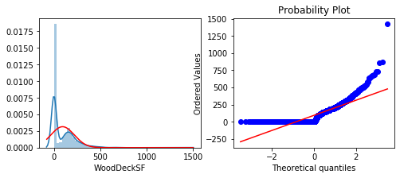

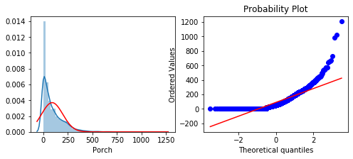

```python
for column in skewed_features:
    fig, axes = plt.subplots(1, 2, figsize = (8,3))
    sns.distplot(data_num[column], kde=True, fit=norm, fit_kws={"color":"red"}, ax=axes[0])
    probplot(data_num[column], plot=plt)
```

```python
def numerical_feature_transfer(df):
    data = df.copy()
    data["LotFrontage"] = st.boxcox(data["LotFrontage"])[0]
    data["LotArea"] =  st.boxcox(data["LotArea"])[0]
    data["MasVnrArea"] = data["MasVnrArea"] **0.25
    data["TotalBsmtSF"] = np.log1p(data["TotalBsmtSF"])
    data["GrLivArea"] = np.log1p(data["GrLivArea"])
    data["WoodDeckSF"] = data["WoodDeckSF"]**0.5
    data["Porch"] = np.log1p(data["Porch"])

    return data
```

```python
transfered_data = numerical_feature_transfer(transfered_data)
```

After transformed, the plot show as below

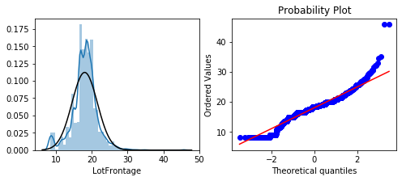

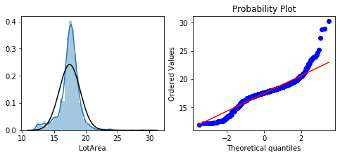

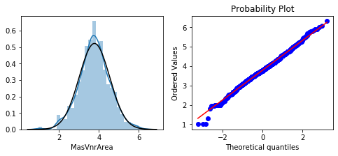

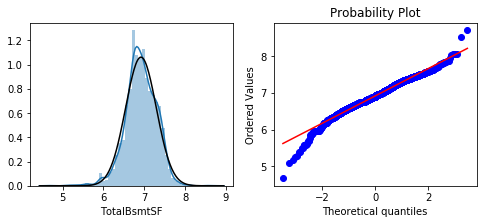

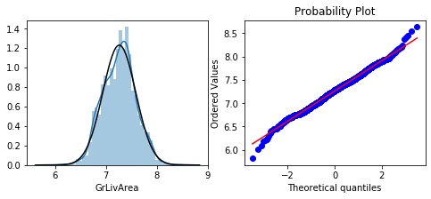

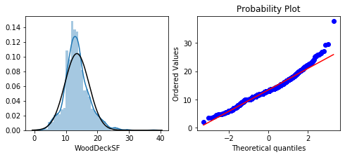

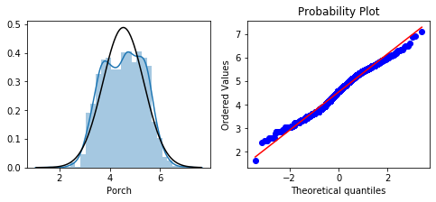

```python
fig, axes = plt.subplots(1, 2, figsize = (8,3))
sns.distplot(transfered_data["LotFrontage"], fit=st.norm, fit_kws={"color":"black"}, ax=axes[0])
plot=probplot(transfered_data["LotFrontage"], plot=plt)

fig, axes = plt.subplots(1, 2, figsize = (8,3))
sns.distplot(transfered_data["LotArea"], fit=st.norm, fit_kws={"color":"black"}, ax=axes[0])
plot=probplot(transfered_data["LotArea"], plot=plt)

fig, axes = plt.subplots(1, 2, figsize = (8,3))
sns.distplot(transfered_data[transfered_data['MasVnrArea']>0]["MasVnrArea"], fit=st.norm, fit_kws={"color":"black"}, ax=axes[0])
plot=probplot(transfered_data[transfered_data['MasVnrArea']>0]["MasVnrArea"], plot=plt)

fig, axes = plt.subplots(1, 2, figsize = (8,3))
sns.distplot(transfered_data[transfered_data['TotalBsmtSF']>0]["TotalBsmtSF"], fit=st.norm, fit_kws={"color":"black"}, ax=axes[0])
plot=probplot(transfered_data[transfered_data['TotalBsmtSF']>0]["TotalBsmtSF"], plot=plt)

fig, axes = plt.subplots(1, 2, figsize = (8,3))
sns.distplot(transfered_data["GrLivArea"], fit=st.norm, fit_kws={"color":"black"}, ax=axes[0])
plot=probplot(transfered_data["GrLivArea"], plot=plt)

fig, axes = plt.subplots(1, 2, figsize = (8,3))
sns.distplot(transfered_data[transfered_data['WoodDeckSF']>0]["WoodDeckSF"], fit=st.norm, fit_kws={"color":"black"}, ax=axes[0])
plot=probplot(transfered_data[transfered_data['WoodDeckSF']>0]["WoodDeckSF"], plot=plt)

fig, axes = plt.subplots(1, 2, figsize = (8,3))
sns.distplot(transfered_data[transfered_data['Porch']>0]["Porch"], fit=st.norm, fit_kws={"color":"black"}, ax=axes[0])
plot=probplot(transfered_data[transfered_data['Porch']>0]["Porch"], plot=plt)
```

## Multicollinearity features

Multicollinearity can cause problem when building regression method as all variables should be independent, and it will also cause undermines the statistical significance of an independent variable. Before we do any furthur treatment. let's take a look of current heatmap. Below heatmap shows the correlation between all numerical features.

```
Index(['LotFrontage', 'LotArea', 'OverallQual', 'YearBuilt', 'MasVnrArea',
       'ExterQual', 'BsmtQual', 'BsmtExposure', 'BsmtFinType1', 'TotalBsmtSF',
       'HeatingQC', 'GrLivArea', 'KitchenQual', 'TotRmsAbvGrd', 'Fireplaces',
       'FireplaceQu', 'GarageFinish', 'GarageCars', 'GarageArea', 'GarageQual',
       'WoodDeckSF', 'Porch', 'TotBathroom', 'Remodel', 'SalePrice'],
      dtype='object')
```

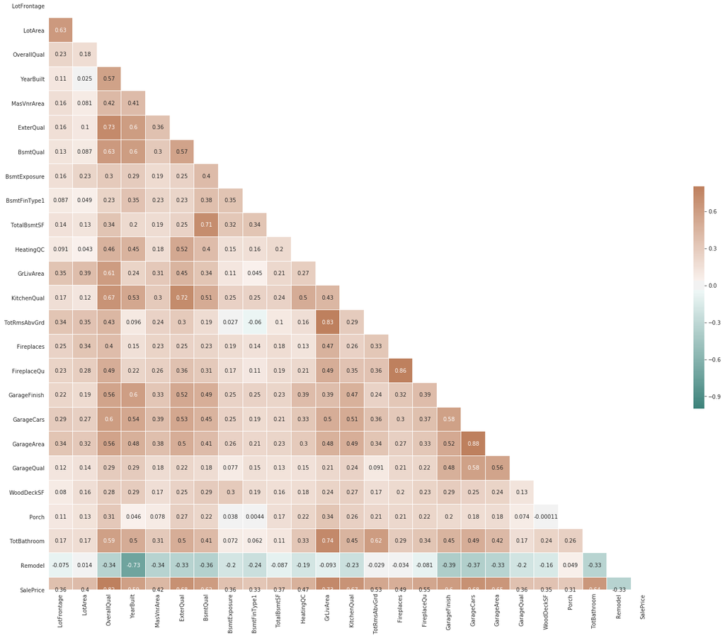

```python
#most corr features to sale price
train_section = pd.concat([transfered_data.iloc[:1460,],Ytrain], axis=1,  sort=False)
corr= train_section.corr()

most_corr_features = corr.index[abs(corr["SalePrice"])>=0.3]

print(most_corr_features)

new_corrmat = train_section[most_corr_features].corr()
#sns.heatmap(new_corrmat,vmax =0.8, annot=True, fmt =".2f",cmap="coolwarm")



#correlation heatmap
mask = np.zeros_like(new_corrmat)
mask[np.triu_indices_from(mask)]=True

cmap = sns.diverging_palette(180, 30, as_cmap=True)

with sns.axes_style('white'):
    fig, ax = plt.subplots(figsize=(25,25))
    sns.heatmap(new_corrmat,  mask=mask, cmap=cmap, annot=True, center=0, vmin=-1, vmax=0.8,
                square=True, cbar_kws={'shrink':.3, 'orientation': 'vertical'}, linewidth=.02);
```

we can see there are many multicollinear features. I will remove one of the feature if their correlation is greater than 0.7. After removed ExterQual, FireplaceQu, GarageArea, KitchenQual, Remodel, TotBathroom, TotRmsAbvGrd, TotalBsmtSF, the heatmap show as below.

```python
def high_multicollinear_features(df, threshold =0.7):
    high_corr_data = df[most_corr_features]
    high_corr_data = high_corr_data.loc[:,high_corr_data.columns != "SalePrice"]
    r = high_corr_data.corr()
    idx = np.abs(np.tril(r, k= -1)) < threshold
    idx_keep = np.all(idx, axis=1)
    data_uncorr = high_corr_data.iloc[:,idx_keep]
    dropped_columns=high_corr_data.columns.difference(high_corr_data.columns[idx_keep])
    #plt.figure(figsize=(12,10))
    #sns.heatmap(data_uncorr.corr(), annot= True, fmt=".2f", cmap="coolwarm")
    mask = np.zeros_like(data_uncorr.corr())
    mask[np.triu_indices_from(mask)]=True
    cmap = sns.diverging_palette(180, 30, as_cmap=True)
    with sns.axes_style('white'):
        fig, ax = plt.subplots(figsize=(25,25))
        sns.heatmap(data_uncorr.corr(),  mask=mask, cmap=cmap, annot=True, center=0, vmin=-1, vmax=0.8,
                square=True, cbar_kws={'shrink':.5, 'orientation': 'vertical'}, linewidth=.02);
    return dropped_columns
```

```
Index(['ExterQual', 'FireplaceQu', 'GarageArea', 'KitchenQual', 'Remodel',
       'TotBathroom', 'TotRmsAbvGrd', 'TotalBsmtSF'],
      dtype='object')
```

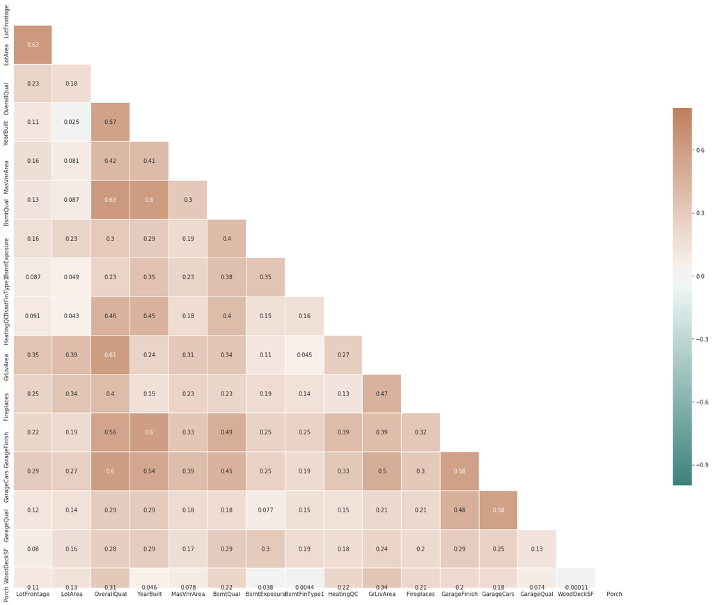

```python
drop_columns = high_multicollinear_features(train_section,threshold =0.7 )
print(drop_columns)
```

```python
data = transfered_data.drop(corr.index[abs(corr["SalePrice"])<0.3], axis =1)
data = transfered_data.drop(drop_columns, axis=1, inplace = False)
```

## Transfer categorical features into dummy variables

Based on the feature defination, I will regroup the categorical variables and transfer into dummy variable.

```python
# categorical features transformation
def categorical_feature_transformation(df):
    data = df.copy()
    data["LotConfig"] = data["LotConfig"].apply(lambda x: "FR" if (x =="FR2" or x =="FR3") else x)
    data["Condition1"] = data["Condition1"].map({"Artery":"Artery","Feedr":"Feedr","Norm":"Norm","RRNn":"RR", "RRAn":"RR",
                                             "RRNe":"RR","RRAe":"RR", "PosN":"Pos", "PosA":"Pos"})
    data["RoofStyle"] = data["RoofStyle"].apply(lambda x: "Other" if (x =="Gambrel" or x =="Mansard"
                                                                  or x=="Shed" or x =="Flat") else x)
   # data["GarageType"] = data["GarageType"].apply(lambda x: "None" if x =="CarPort" else ("Attchd" if x=="2Types" else x))
    data["GarageType"] = data["GarageType"].map({"Attchd":"Attchd", "BuiltIn":"Attchd",
                                                 "Basement":"Attchd","2Types":"Attchd",
                                                "Carport":"None", "None":"None",
                                                "Detchd":"Detchd" })

    data["SaleType"] = data["SaleType"].map({"WD":"WD","CWD":"WD","VWD":"WD",
                                         "New":"New",
                                         "COD":"COD",
                                         "Con":"Con","ConLw":"Con","ConLI":"Con","ConLD":"Con",
                                        "Oth":"Other"})
    data = data.drop(["MoSold","YrSold"], axis = 1, inplace= False)
    return data
```

```python
data_new = categorical_feature_transformation(data)
```

```python
data_new
```

|  | MSSubClass | MSZoning | LotFrontage | LotArea | LotShape | LandContour | LotConfig | Neighborhood | Condition1 | BldgType | HouseStyle | OverallQual | OverallCond | YearBuilt | RoofStyle | Exterior1st | Exterior2nd | MasVnrType | MasVnrArea | ExterCond | Foundation | BsmtQual | BsmtCond | BsmtExposure | BsmtFinType1 | HeatingQC | GrLivArea | BsmtFullBath | BedroomAbvGr | … |
| --- | --- | --- | --- | --- | --- | --- | --- | --- | --- | --- | --- | --- | --- | --- | --- | --- | --- | --- | --- | --- | --- | --- | --- | --- | --- | --- | --- | --- | --- | --- |
| 0 | 60 | RL | 17.477147 | 17.233406 | 4 | 4 | Inside | CollgCr | Norm | 1Fam | 2Story | 7 | 5 | 2003 | Gable | VinylSd | VinylSd | BrkFace | 3.741657 | 3 | PConc | 4 | 3 | 1 | 6 | 5 | 7.444833 | 1 | 3 | … |
| 1 | 20 | RL | 19.917336 | 17.650449 | 4 | 4 | FR | Veenker | Feedr | 1Fam | 1Story | 6 | 8 | 1976 | Gable | MetalSd | MetalSd | None | 0.000000 | 3 | CBlock | 4 | 3 | 4 | 5 | 5 | 7.141245 | 0 | 3 | … |
| 2 | 60 | RL | 17.982878 | 18.178584 | 3 | 4 | Inside | CollgCr | Norm | 1Fam | 2Story | 7 | 5 | 2001 | Gable | VinylSd | VinylSd | BrkFace | 3.567621 | 3 | PConc | 4 | 3 | 2 | 6 | 5 | 7.488294 | 1 | 3 | … |
| 3 | 70 | RL | 16.611691 | 17.633246 | 3 | 4 | Corner | Crawfor | Norm | 1Fam | 2Story | 7 | 5 | 1915 | Gable | Wd Sdng | Wd Shng | None | 0.000000 | 3 | BrkTil | 3 | 4 | 1 | 5 | 4 | 7.448916 | 1 | 3 | … |
| 4 | 60 | RL | 20.534307 | 18.988661 | 3 | 4 | FR | NoRidge | Norm | 1Fam | 2Story | 8 | 5 | 2000 | Gable | VinylSd | VinylSd | BrkFace | 4.325308 | 3 | PConc | 4 | 3 | 3 | 6 | 5 | 7.695758 | 1 | 4 | … |
| ... | ... | ... | ... | ... | ... | ... | ... | ... | ... | ... | ... | ... | ... | ... | ... | ... | ... | ... | ... | ... | ... | ... | ... | ... | ... | ... | ... | ... | ... | … |
| 2914 | 160 | RM | 8.287929 | 12.886866 | 4 | 4 | Inside | MeadowV | Norm | Twnhs | 2Story | 4 | 7 | 1970 | Gable | CemntBd | CmentBd | None | 0.000000 | 3 | CBlock | 3 | 3 | 1 | 1 | 4 | 6.996681 | 0 | 3 | … |
| 2915 | 160 | RM | 8.287929 | 12.828255 | 4 | 4 | Inside | MeadowV | Norm | TwnhsE | 2Story | 4 | 5 | 1970 | Gable | CemntBd | CmentBd | None | 0.000000 | 3 | CBlock | 3 | 3 | 1 | 3 | 3 | 6.996681 | 0 | 3 | … |
| 2916 | 20 | RL | 30.538929 | 20.188570 | 4 | 4 | Inside | Mitchel | Norm | 1Fam | 1Story | 5 | 7 | 1960 | Gable | VinylSd | VinylSd | None | 0.000000 | 3 | CBlock | 3 | 3 | 1 | 5 | 5 | 7.110696 | 1 | 4 | … |
| 2917 | 85 | RL | 16.961412 | 17.928726 | 4 | 4 | Inside | Mitchel | Norm | 1Fam | SFoyer | 5 | 5 | 1992 | Gable | HdBoard | Wd Shng | None | 0.000000 | 3 | PConc | 4 | 3 | 3 | 6 | 3 | 6.878326 | 0 | 3 | … |
| 2918 | 60 | RL | 18.966761 | 17.659707 | 4 | 4 | Inside | Mitchel | Norm | 1Fam | 2Story | 7 | 5 | 1993 | Gable | HdBoard | HdBoard | BrkFace | 3.113737 | 3 | PConc | 4 | 3 | 3 | 2 | 5 | 7.601402 | 0 | 3 | … |

2919 rows × 39 columns

```python
quantitivie_columns = ['LotFrontage', 'LotArea', 'MasVnrArea', 'GrLivArea', 'WoodDeckSF',
       'Porch','YearBuilt','BsmtFullBath','BedroomAbvGr','Fireplaces','GarageCars']

ordinal_columns = ['LotShape', 'LandContour', 'OverallQual', 'OverallCond', 'ExterCond',
                    'BsmtQual', 'BsmtCond', 'BsmtExposure', 'BsmtFinType1','HeatingQC',
                     'GarageFinish',  'GarageQual']
cat_columns = ['MSSubClass', 'MSZoning', 'LotConfig', 'Neighborhood', 'Condition1',
       'BldgType', 'HouseStyle', 'RoofStyle', 'Exterior1st', 'Exterior2nd',
       'MasVnrType', 'Foundation', 'GarageType', 'Fence', 'SaleType',
       'SaleCondition']
#print('We have {} columns : \n{}'.format(len(train_data.columns),train_data.columns.values))
#train_data.columns

print("There are {} quantitivie columns \n".format(len(quantitivie_columns)))
print("There are {} ordinial columns \n".format(len(ordinal_columns)))
print("There are {} categorical columns \n".format(len(cat_columns)))
print("total {} columns".format((len(quantitivie_columns))+len(ordinal_columns)
     +len(cat_columns)))
data_new.shape
```

```
There are 11 quantitivie columns

There are 12 ordinial columns

There are 16 categorical columns

total 39 columns
```

```
(2919, 39)
```

```python
quantitive = data_new[quantitivie_columns]
ordinal = data_new[ordinal_columns]
factor = data_new[cat_columns]
factor_dummies = pd.get_dummies(factor)
final_data = pd.concat([quantitive,ordinal, factor_dummies], axis =1)
final_data.shape
```

```
(2919, 155)
```

# Modelling

Sale price is continue numerical features, so regression is the proper method for this kind of data. I will try different regression algorithms:

- Linear Regression
- Ridge Regression
- Lasso Regression
- Elastic Net Regression
- Support Vector Regression Regression
- Decision Tree Regression
- Random Forest Regression
- XGBoost Regression

For each algorithms, I will perform parameter tuning, using RMSE to choose the best score parameter, then compare them together. Five folds cross validation will be performed.

## split the train and test data

```python
Xtrain = final_data.iloc[:1460,].drop(outlier_index)
Ytrain = Ytrain.drop(outlier_index)

Xtest = final_data.iloc[1460:,]
Ytest = np.log(Y_test["SalePrice"])
```

## create RMSE(root-mean-square error) metric

```python
# Creation of the RMSE metric:
n_folds = 5
kfold = KFold(n_folds, shuffle=True, random_state=42).get_n_splits(Xtrain)

def rmse(y, y_pred):
    return np.sqrt(mean_squared_error(y, y_pred))

def rmse_cv(model):
    rmse = np.sqrt(-cross_val_score(model, Xtrain, Ytrain, scoring="neg_mean_squared_error", cv=kfold, verbose= 0))
    return (rmse)
```

```python
# Linear Regression
linear_reg = LinearRegression()
rmse_linear_reg = rmse_cv(linear_reg)
#print(rmse_linear_reg.mean())
#rmse_std.append(round(rmse_linear_reg.std(),3))

print("Linar regression RMSE is: ",round(rmse_linear_reg.mean(),3) )
print("Linar regression RMSE standard deviation is: ",round(rmse_linear_reg.std(),3) )
```

```
Linar regression RMSE is:  0.119
Linar regression RMSE standard deviation is:  0.008
```

```
{'alpha': 3}
```

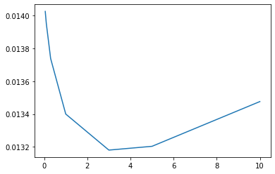

```python
#Ridge
parametersGrid = {"alpha": [0.05, 0.1, 0.3, 1, 3, 5,10]}
kf = KFold(n_splits= 5)
ridge = Ridge()
ridge_grid = GridSearchCV(ridge, parametersGrid, scoring = "neg_mean_squared_error", cv= kf)
ridge_grid.fit(Xtrain, Ytrain)

plt.plot([0.05, 0.1, 0.3, 1, 3, 5,10], -ridge_grid.cv_results_["mean_test_score"])
ridge_grid.best_params_
```

```
{'alpha': 0.0001}
```

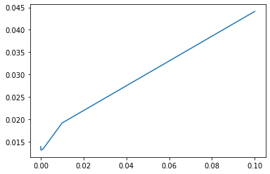

```python
#lasso
parametersGrid = {"alpha": [0.00001, 0.0001, 0.001, 0.01, 0.1]}
kf = KFold(n_splits= 5)
lasso = Lasso()
lasso_grid = GridSearchCV(lasso, parametersGrid, scoring = "neg_mean_squared_error", cv= kf)
lasso_grid.fit(Xtrain, Ytrain)

plt.plot([0.00001, 0.0001, 0.001, 0.01, 0.1], -lasso_grid.cv_results_["mean_test_score"])
lasso_grid.best_params_
#lasso_grid.cv_results_
```

```python
# elastic Net
parametersGrid = {"alpha": [0.0001, 0.005, 0.1, 0.3, 0.5, 0.7, 0.9, 1, 2],
                 "l1_ratio": [0.01,0.1,0.3,0.5,0.7,0.9, 1]
                }

#parametersGrid = {
#                  "alpha": [0.0005, 0.005, 0.001, 0.01, 0.1, 1, 10, 100],
#                  "l1_ratio": np.arange(0.0, 1.0, 0.1)}
kf = KFold(n_splits= 5)
ridge = ElasticNet()
ridge_grid = GridSearchCV(ridge, parametersGrid, scoring = "neg_mean_squared_error", cv= kf)
ridge_grid.fit(Xtrain, Ytrain)

#plt.plot([0.05, 0.1, 0.3, 1, 3, 5,10], -ridge_grid.cv_results_["mean_test_score"])
ridge_grid.best_params_
#lasso_grid.cv_results_
```

```
{'alpha': 0.0001, 'l1_ratio': 1}
```

```python
parametersGrid = {"n_estimators": [360, 500],
                 "max_depth": [2,3,5],
                  "eta": [0.01,0.1,0.2,0.3],
                  "min_child_weight": [1,2],
                  "colsample_bytree": [0.7, 0.8],
                  "subsample": [0.7, 0.8]
                }
kf = KFold(n_splits= 5)
XBG = xgb.XGBRegressor()
XGB_grid = GridSearchCV(XBG, parametersGrid, scoring = "neg_mean_squared_error", cv= kf, n_jobs=-1)
XGB_grid.fit(Xtrain, Ytrain)
XGB_grid.best_params_
```

```python
#DecisionTree Regression
DTR = DecisionTreeRegressor()
parameters = { 'criterion':["mse"],
               'max_depth':[3,5,7] ,
              'max_features':["auto","sqrt"] ,
             'max_leaf_nodes':[None,5,10, 12,15,18,20] ,
              'min_samples_split':[10,15,20,30]
             }
grid_search= GridSearchCV(DTR, parameters, cv=5, verbose=1 , scoring = "neg_mean_squared_error", n_jobs=-1)
grid_search.fit(Xtrain, Ytrain)

DTR_score=grid_search.best_score_
DTR_params=grid_search.best_params_
print(DTR_score)
print(DTR_params)
```

```
Fitting 5 folds for each of 168 candidates, totalling 840 fits
```

```
[Parallel(n_jobs=-1)]: Using backend LokyBackend with 8 concurrent workers.
[Parallel(n_jobs=-1)]: Done  60 tasks      | elapsed:    0.5s
```

```
-0.03721192162877289
{'criterion': 'mse', 'max_depth': 7, 'max_features': 'auto', 'max_leaf_nodes': None, 'min_samples_split': 30}
```

```
[Parallel(n_jobs=-1)]: Done 840 out of 840 | elapsed:    2.2s finished
```

```python
#RandomForest Regression
RFR=RandomForestRegressor()
parameters = {'min_samples_split' : [3,4,6,10],
              'n_estimators' : [50, 70,100, 200] ,
             'max_features':["auto", "sqrt", "log2"]}
grid_search= GridSearchCV(RFR, parameters, cv=5, verbose=1 , scoring = "neg_mean_squared_error", n_jobs=-1)
grid_search.fit(Xtrain, Ytrain)

RFR_score=grid_search.best_score_
RFR_params=grid_search.best_params_
print(RFR_score)
print(RFR_params)
```

```
[Parallel(n_jobs=-1)]: Using backend LokyBackend with 8 concurrent workers.
```

```
Fitting 5 folds for each of 48 candidates, totalling 240 fits
```

```
[Parallel(n_jobs=-1)]: Done  34 tasks      | elapsed:   10.1s
[Parallel(n_jobs=-1)]: Done 184 tasks      | elapsed:   29.2s
[Parallel(n_jobs=-1)]: Done 240 out of 240 | elapsed:   33.3s finished
```

```
-0.01946209118867912
{'max_features': 'auto', 'min_samples_split': 6, 'n_estimators': 200}
```

```python
from sklearn.pipeline import make_pipeline
from sklearn.preprocessing import RobustScaler
import xgboost as xgb
from sklearn.ensemble import GradientBoostingRegressor
from sklearn.preprocessing import StandardScaler
base_models = {"Linear Regression": LinearRegression(),
               "Lasso" :  Lasso(alpha =0.0001),
               "Ridge" : Ridge(alpha= 3),
               "Elastic Net": ElasticNet(alpha=0.0001, l1_ratio =1),
               "SVM": SVR(gamma = 'auto'),
               "Random Forest": RandomForestRegressor(max_features = 'auto', min_samples_split = 6, n_estimators = 200),
               "Decision Tree": DecisionTreeRegressor(criterion='mse', max_depth = 7, max_features='auto',
                                                      max_leaf_nodes =None, min_samples_split =20),
               "XGBoost": xgb.XGBRegressor(colsample_bytree = 0.7, eta = 0.1, max_depth = 2,
                            min_child_weight = 2,   n_estimators = 500,  subsample=0.7)
              }
```

```python
r_2_results = {'R-Squared':{},'Mean':{},'std':{}}
rmse_results = {'RMSE':{},'Mean':{},'std':{}}

n_folds = 5
kfold = KFold(n_folds, shuffle=True, random_state=42).get_n_splits(Xtrain)

for name in base_models:
    model = base_models[name]
    r_2 = cross_val_score(model, Xtrain, Ytrain, scoring='r2', cv=kfold)   #R-Squared
    rms = np.sqrt(-cross_val_score(model, Xtrain, Ytrain, cv=kfold,        #RMSE
                                   scoring='neg_mean_squared_error'))

    #save the R-Squared reults
    r_2_results['R-Squared'][name] = r_2
    r_2_results['Mean'][name] = r_2.mean()
    r_2_results['std'][name] = r_2.std()

    #save the RMSE reults
    rmse_results['RMSE'][name] = rms
    rmse_results['Mean'][name] = rms.mean()
    rmse_results['std'][name] = rms.std()


#baseline_models = ['Linear_Reg', "Ridge","Lasso", "ElasticNet", "SVM", "Decision Tree",
#                   "Random Forest", "KNN","Gradient Boosting"]
```

```python
from plotly.offline import iplot
import cufflinks as cf
cf.go_offline()
cf.set_config_file(offline=False, world_readable=True)

r_2_cv_results = pd.DataFrame(index=r_2_results['R-Squared'].keys())

#append the max R-Squared for each model to the dataframe
r_2_cv_results['Max'] = [r_2_results['R-Squared'][m].max() for m in r_2_results['R-Squared'].keys()]
#append the mean of all R-Squared for each model to the dataframe
r_2_cv_results['Mean'] = [r_2_results['Mean'][m] for m in r_2_results['Mean'].keys()]
#append the min R-Squared for each model to the dataframe
r_2_cv_results['Min'] = [r_2_results['R-Squared'][m].min() for m in r_2_results['R-Squared'].keys()]
#append the std of all R-Squared for each model to the dataframe
r_2_cv_results['std'] = [r_2_results['std'][m] for m in r_2_results['std'].keys()]

r_2_cv_results = r_2_cv_results.sort_values(by='Mean',ascending=False)
r_2_cv_results.iplot(kind='bar',title='Max, Min, Mean, and standard deviation <br>For R-Squared values for each model')
```

[interactive chart not shown]

```python
scores = pd.DataFrame(r_2_results['R-Squared'])
#r_2_cv_results = r_2_cv_results.sort_values(by='Mean',ascending=False)
scores.iplot(kind='box',
             title='Box plot for the variation of R-Squared for each model')
```

[interactive chart not shown]

```python
#visualize the results of RMSE for each model

rmse_cv_results = pd.DataFrame(index=rmse_results['RMSE'].keys())

#append the max R-Squared for each model to the dataframe
rmse_cv_results['Max'] = [rmse_results['RMSE'][m].max() for m in rmse_results['RMSE'].keys()]
#append the mean of all R-Squared for each model to the dataframe
rmse_cv_results['Mean'] = [rmse_results['Mean'][m] for m in rmse_results['Mean'].keys()]
#append the min R-Squared for each model to the dataframe
rmse_cv_results['Min'] = [rmse_results['RMSE'][m].min() for m in rmse_results['RMSE'].keys()]
#append the std of all R-Squared for each model to the dataframe
rmse_cv_results['std'] = [rmse_results['std'][m] for m in rmse_results['std'].keys()]

rmse_cv_results = rmse_cv_results.sort_values(by='Mean',ascending=True)
rmse_cv_results.iplot(kind='bar',
                 title='Maximum, Minimun, Mean values and standard deviation <br>For RMSE values for each model')
```

[interactive chart not shown]

```python
#visualize the variance of RMSE for each model

scores = pd.DataFrame(rmse_results['RMSE'])
scores.iplot(kind='box',
             title='Box plot for the variation of RMSE values for each model')
```

[interactive chart not shown]

Based on the above comparation from $R^2$ and RMSE, XGBoost is the best model from ensemble Machine Learning . All linear regression model have similar performance. As Ridge has regularization. I choose Ridge method for furthur validaiton.

```
XGBoost picked 135 features and eliminated the other 20 features
```

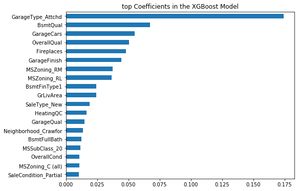

```python
XGB = xgb.XGBRegressor(colsample_bytree = 0.7, eta = 0.1, max_depth = 3,
                            min_child_weight = 1,   n_estimators = 500,  subsample=0.8)
#XGB = Ridge(alpha= 3)
XGB.fit(Xtrain, Ytrain)
coefs = pd.Series(XGB.feature_importances_, index = Xtrain.columns)
xgb_impt=coefs[abs(coefs)>0.01].sort_values(ascending=True)
print("XGBoost picked " + str(sum(coefs != 0)) + " features and eliminated the other " +  str(sum(coefs == 0)) + " features")

plt.figure(figsize=(8, 6))
xgb_impt.plot(kind = "barh")
plt.title("top Coefficients in the XGBoost Model")
```

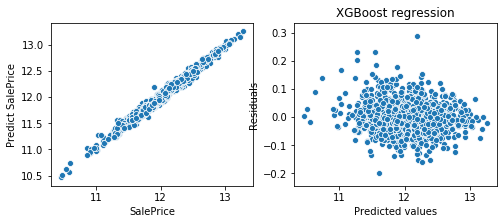

```python
Ytrain_pred = XGB.predict(Xtrain)
fig, axes = plt.subplots(1, 2, figsize = (8,3))
#sns.scatterplot(Ytrain_pred, Ytrain_pred-Ytrain, c = "lightgreen",  label = "Validation data", ax = axes[0])
#plt.scatter(np.exp(Ytrain_pred), np.exp(Ytrain), c = "lightgreen",  label = "Validation data",ax = axes[1]))
xg=sns.scatterplot( x=Ytrain, y = Ytrain_pred, ax=axes[0])
xg.set(xlabel='SalePrice', ylabel='Predict SalePrice')
sns.scatterplot( x=Ytrain_pred, y = Ytrain_pred-Ytrain, ax=axes[1])
plt.title("XGBoost regression")
plt.xlabel("Predicted values")
plt.ylabel("Residuals")
```

```
Ridge picked 153 features and eliminated the other 20 features
```

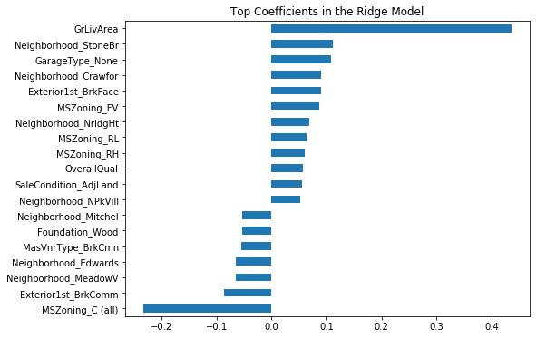

```python
Ridge_reg = Ridge(alpha= 3)
Ridge_reg.fit(Xtrain, Ytrain)

r_coefs = pd.Series(Ridge_reg.coef_, index = Xtrain.columns)

#coefs = pd.Series(XGB.feature_importances_, index = Xtrain.columns)
ridge_impt=r_coefs[abs(r_coefs)>0.05].sort_values(ascending=True)
print("Ridge picked " + str(sum(r_coefs != 0)) + " features and eliminated the other " +  str(sum(coefs == 0)) + " features")

plt.figure(figsize=(8, 6))
ridge_impt.plot(kind = "barh")
plt.title("Top Coefficients in the Ridge Model")
```

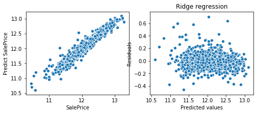

```python
Ytrain_pred = Ridge_reg.predict(Xtrain)
fig, axes = plt.subplots(1, 2, figsize = (8,3))
#sns.scatterplot(Ytrain_pred, Ytrain_pred-Ytrain, c = "lightgreen",  label = "Validation data", ax = axes[0])
#plt.scatter(np.exp(Ytrain_pred), np.exp(Ytrain), c = "lightgreen",  label = "Validation data",ax = axes[1]))
rg=sns.scatterplot( x=Ytrain, y = Ytrain_pred, ax=axes[0])
rg.set(xlabel='SalePrice', ylabel='Predict SalePrice')
sns.scatterplot( x=Ytrain_pred, y = Ytrain_pred-Ytrain, ax=axes[1])
plt.title("Ridge regression")
plt.xlabel("Predicted values")
plt.ylabel("Residuals")
```

```python
xgb_impt.index
```

```
Index(['SaleCondition_Partial', 'MSZoning_C (all)', 'OverallCond',
       'MSSubClass_20', 'BsmtFullBath', 'Neighborhood_Crawfor', 'GarageQual',
       'HeatingQC', 'SaleType_New', 'GrLivArea', 'BsmtFinType1', 'MSZoning_RL',
       'MSZoning_RM', 'GarageFinish', 'Fireplaces', 'OverallQual',
       'GarageCars', 'BsmtQual', 'GarageType_Attchd'],
      dtype='object')
```

# Conclusion

XGBoost and linear, Lasso, Ridge, ElasticNet regressons have decent $R^2$ and RMSE. They are much better than Random Forests, SVM and Desicion tree. Based on the XGBoost model, the TOP 10 features that influence the sale price are GrLivArea, BsmtFinType1, MSZoning_RL, MSZoning_RM, GarageFinish, Fireplaces, OverallQual, GarageCars, BsmtQual, GarageType_Attchd. For a seller, many of the features cannot be easily changed. There is one area that can add significant value to a home which is improve the overall quality.

# furture improvement

There are some interaction between some features, like OveralConditon and Overal Quality, Kitchen condition and kitchen quality. I will add the interaction into the model to improve the model perfomance. Also, may add polynomial as well. Another way to improve the prediction is using stacking ensemble machine learning.